© Bản quyền thuộc về Quantopian Inc.  
© Bản quyền sửa đổi thuộc về AI Cafe¹  
Giấy phép [Creative Commons Attribution 4.0](https://creativecommons.org/licenses/by/4.0/legalcode).  
[Khuyến cáo](https://aicafe.one/khuyen-cao/)

# Phân tích phần dư (Residuals Analysis)

By Chris Fenaroli and Max Margenot

Edited by AI Cafe¹

## Hồi Quy Tuyến Tính

Hồi quy tuyến tính là một trong những kỹ thuật mô hình cơ bản nhất của chúng ta. Chúng ta sử dụng nó để ước lượng một mối quan hệ tuyến tính giữa một tập hợp các biến độc lập $X_i$ và một biến kết quả phụ thuộc $y$. Mô hình của chúng ta có dạng:

$$ y_i = \beta_{0} 1 + \beta_{i, 1} x_{i, 1} + \dots + \beta_{i, p} x_{i, p} + \epsilon_i = x_i'\beta + \epsilon_i $$

Đối với $i \in \{1, \dots, n\}$, trong đó $n$ là số lượng quan sát. Chúng ta viết điều này dưới dạng vector như sau:

$$ y = X\beta + \epsilon $$

Trong đó $y$ là một vector $n \times 1$, $X$ là một ma trận $n \times p$, $\beta$ là một vector hệ số $p \times 1$, và $\epsilon$ là một thành phần lỗi chuẩn. Thông thường, chúng ta gọi một mô hình với $p = 1$ là hồi quy tuyến tính đơn giản và một mô hình với $p > 1$ là hồi quy tuyến tính bội. Thông tin nền tảng hơn về hồi quy có thể được tìm thấy trong các bài giảng về hồi quy tuyến tính đơn giản và hồi quy tuyến tính bội.

Mỗi khi chúng ta xây dựng một mô hình, sẽ có sự chênh lệch giữa những gì mà mô hình dự đoán và những gì được quan sát trong mẫu. Sự khác biệt giữa các giá trị này được gọi là phần dư của mô hình và có thể được sử dụng để kiểm tra một số giả định cơ bản mà mô hình dựa vào. Các giả định chính cần kiểm tra là:

- **Khớp Tuyến Tính:** Mối quan hệ cơ bản nên là tuyến tính
- **Homoscedastic:** Dữ liệu không nên có xu hướng trong phương sai
- **Phân Phối Độc Lập và Đồng Nhất:** Các phần dư của hồi quy nên độc lập và phân phối đồng nhất (i.i.d.) và không có dấu hiệu tương quan chuỗi

Chúng ta có thể sử dụng các phần dư để giúp chẩn đoán xem mối quan hệ mà chúng ta ước lượng có thực sự hay không.

Lỗi thống kê là một chỉ số tương tự liên quan đến phân tích hồi quy với một sự khác biệt quan trọng: Trong khi các phần dư định lượng khoảng cách giữa dự đoán của mô hình hồi quy và mẫu quan sát, lỗi thống kê là sự khác biệt giữa mô hình hồi quy và giá trị kỳ vọng không thể quan sát. Chúng ta sử dụng các phần dư trong nỗ lực ước lượng lỗi này.

```python
# Import libraries
import numpy as np
import statsmodels.api as sm
import statsmodels.stats.diagnostic as smd
import scipy.stats as stats
import matplotlib.pyplot as plt
```

### Hồi Quy Tuyến Tính Đơn Giản

Đầu tiên, chúng ta sẽ định nghĩa một hàm thực hiện hồi quy tuyến tính và vẽ biểu đồ kết quả.

```python
def linreg(X,Y):
    # Running the linear regression
    X = sm.add_constant(X)
    model = sm.OLS(Y, X).fit()
    B0 = model.params[0]
    B1 = model.params[1]
    X = X[:, 1]

    # Return summary of the regression and plot results
    X2 = np.linspace(X.min(), X.max(), 100)
    Y_hat = X2 * B1 + B0
    plt.scatter(X, Y, alpha=1) # Plot the raw data
    plt.plot(X2, Y_hat, 'r', alpha=1);  # Add the regression line, colored in red
    plt.xlabel('X Value')
    plt.ylabel('Y Value')
    return model, B0, B1
```

Chúng ta hãy định nghĩa một mối quan hệ đơn giản giữa $X$ và $Y$ mà chúng ta có thể mô hình hóa bằng hồi quy tuyến tính.

```
Line of best fit: Y = 10.66329403728246 + 0.48859440354517786*X
```

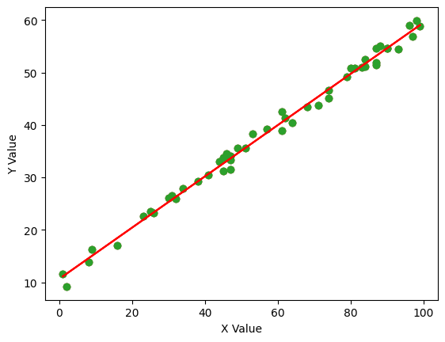

```python
n = 50
X = np.random.randint(0, 100, n)
epsilon = np.random.normal(0, 1, n)

Y = 10 + 0.5 * X + epsilon

linreg(X,Y)[0];
print("Line of best fit: Y = {0} + {1}*X".format(linreg(X, Y)[1], linreg(X, Y)[2]))
```

Ví dụ này có một số nhiễu được tạo ra, nhưng tất cả dữ liệu thực cũng sẽ có nhiễu. Điều này là vốn có trong việc lấy mẫu từ bất kỳ loại quy trình sinh dữ liệu nào. Kết quả là, đường hồi quy tốt nhất của chúng ta sẽ không bao giờ hoàn toàn khớp với dữ liệu (đó là lý do tại sao nó chỉ được gọi là "tốt nhất", không phải "hoàn hảo"). Có một mô hình khớp với từng quan sát mà bạn có là dấu hiệu chắc chắn của hiện tượng overfitting.

Đối với tất cả các mô hình khớp, sẽ có sự khác biệt giữa những gì mô hình hồi quy dự đoán và những gì đã được quan sát, và đó là nơi mà phần dư xuất hiện.

## Phần dư

Định nghĩa của phần dư là sự khác biệt giữa những gì được quan sát trong mẫu và những gì được dự đoán bởi hồi quy. Đối với bất kỳ phần dư nào $r_i$, chúng ta biểu thị điều này như sau:

$$r_i = Y_i - \hat{Y_i}$$

Trong đó $Y_i$ là giá trị $Y$ quan sát được và $\hat{Y}_i$ là giá trị $Y$ dự đoán. Chúng ta vẽ những khác biệt này trên đồ thị sau:

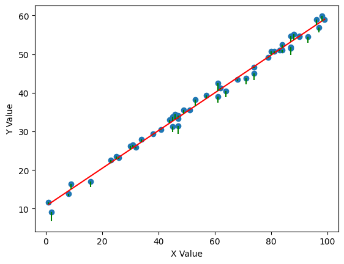

```python
model, B0, B1 = linreg(X,Y)

residuals = model.resid
plt.errorbar(X,Y,xerr=0,yerr=[abs(residuals),0*residuals],linestyle="None",color='Green');
```

Chúng ta có thể lấy trực tiếp các phần dư từ mô hình hồi quy đã phù hợp.

```python
residuals = model.resid
print(residuals)
```

```
[-1.31591161  0.61305576 -1.19124634  1.74341911 -0.22039556  1.35763567
 -0.25013519  1.09823976 -0.63654214 -0.12010138 -1.59912869 -1.49262198
  1.44748376 -1.75407641 -0.37764243 -0.63731284 -0.15113757  0.84204892
  0.67023666 -1.67156231  1.29463347 -2.13320844 -0.38816249 -1.42860061
 -0.03604969  0.77076166  0.827867    1.42293744  1.36041393  0.81802464
 -1.57237913  1.39906493  0.53619824 -0.25614152  0.47468113  0.31433923
  0.95405851 -1.51379425  2.01459853 -0.12384142  0.48885046  0.70594674
 -0.06828536 -2.43815139  0.06006979 -1.37343896  0.69130523  1.01553119
 -0.21523848  0.04370446]
```

### Chẩn đoán phần dư

Nhiều giả định cần thiết để có một mô hình hồi quy tuyến tính hợp lệ có thể được kiểm tra bằng cách xác định các mẫu trong phần dư của mô hình đó. Chúng ta có thể thực hiện một kiểm tra hình ảnh nhanh bằng cách nhìn vào đồ thị phần dư của một mô hình nhất định.

Với đồ thị phần dư, chúng ta nhìn vào các giá trị dự đoán của mô hình so với các phần dư của chính nó. Điều chúng ta muốn thấy là chỉ một đám mây các điểm không liên quan, như thế này:

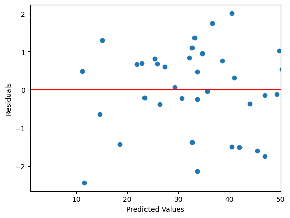

```python
plt.scatter(model.predict(), residuals);
plt.axhline(0, color='red')
plt.xlabel('Predicted Values');
plt.ylabel('Residuals');
plt.xlim([1,50]);
```

Điều chúng ta muốn là một phân phối ngẫu nhiên cho các phần dư. Các điểm dữ liệu không nên tạo thành bất kỳ mẫu nào có thể nhận diện. Điều này sẽ chỉ ra rằng một mô hình tuyến tính đơn giản có khả năng phù hợp tốt. Nếu chúng ta thấy bất kỳ xu hướng nào, điều này có thể chỉ ra sự hiện diện của tự tương quan hoặc độ phân tán không đồng nhất trong mô hình.

## Tính phù hợp của Mô hình Tuyến tính

Bằng cách tìm kiếm các mẫu trong các biểu đồ phần dư, chúng ta có thể xác định liệu một mô hình tuyến tính có phù hợp hay không ngay từ đầu. Một hồi quy tuyến tính đơn thuần sẽ không phù hợp cho một mối quan hệ cơ bản có dạng:

$$Y = \beta_0 + \beta_1 X^2$$

vì một hàm tuyến tính sẽ không thể giải thích đầy đủ mối quan hệ giữa $X$ và $Y$.

Nếu mối quan hệ không phù hợp với một mô hình tuyến tính, biểu đồ phần dư sẽ cho thấy một mẫu rõ ràng. Nói chung, một biểu đồ phần dư của hồi quy tuyến tính trên một mối quan hệ phi tuyến sẽ cho thấy sự thiên lệch và không đối xứng với đường dư = 0, trong khi một biểu đồ phần dư của hồi quy tuyến tính trên một mối quan hệ tuyến tính sẽ thường đối xứng xung quanh trục dư = 0.

Ví dụ, hãy xem xét một mối quan hệ mới giữa các biến $X$ và $Y$ mà bao gồm một thành phần bậc hai.

```
beta_0: 17.77832801097992
beta_1: -2.2826980913857513
```

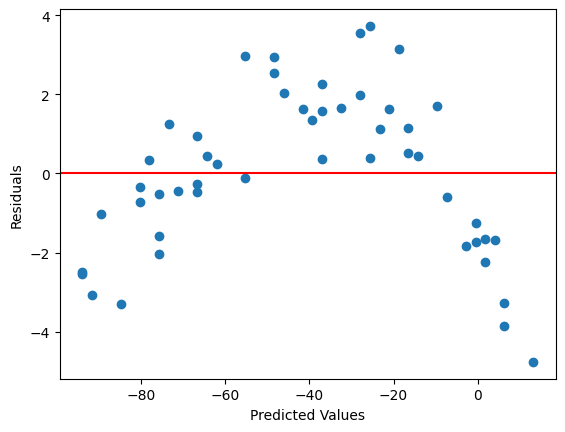

```python
n = 50
X = np.random.randint(0, 50, n)
epsilon = np.random.normal(0, 1, n)
Y_nonlinear = 10 - X**1.2 + epsilon

model = sm.OLS(Y_nonlinear, sm.add_constant(X)).fit()
B0, B1 = model.params
residuals = model.resid

print('beta_0:', B0)
print('beta_1:', B1)
plt.scatter(model.predict(), residuals);
plt.axhline(0, color='red')
plt.xlabel('Predicted Values');
plt.ylabel('Residuals');
```

Hình dạng "chữ U ngược" mà các dư cho thấy là một dấu hiệu cho thấy một mô hình phi tuyến có thể phù hợp hơn so với một mô hình tuyến tính.

## Tính không đồng nhất (Heteroscedasticity)

Một trong những giả định chính của hồi quy tuyến tính là dữ liệu cơ bản có phương sai không đổi. Nếu có một số phần của dữ liệu có phương sai khác với các phần khác, dữ liệu đó sẽ không phù hợp cho hồi quy tuyến tính. **Tính không đồng nhất** là thuật ngữ chỉ dữ liệu có phương sai không đồng nhất, trái ngược với tính đồng nhất, khi dữ liệu có phương sai không đổi.

Tính không đồng nhất đáng kể sẽ làm mất hiệu lực kết quả hồi quy tuyến tính bằng cách thiên lệch sai số chuẩn của mô hình. Do đó, chúng ta không thể tin tưởng vào kết quả của các bài kiểm tra ý nghĩa và khoảng tin cậy được tạo ra từ mô hình và các tham số của nó.

Để tránh những hậu quả này, điều quan trọng là sử dụng biểu đồ dư để kiểm tra tính không đồng nhất và điều chỉnh nếu cần thiết.

Như một ví dụ về việc phát hiện và sửa chữa tính không đồng nhất, hãy xem xét một mối quan hệ khác giữa $X$ và $Y$:

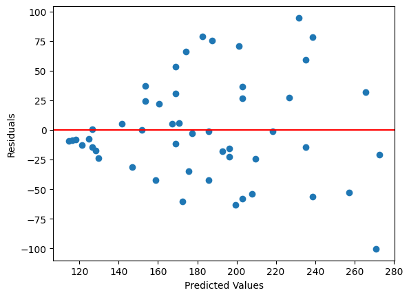

```python
n = 50
X = np.random.randint(0, 100, n)
epsilon = np.random.normal(0, 1, n)
Y_heteroscedastic = 100 + 2*X + epsilon*X

model = sm.OLS(Y_heteroscedastic, sm.add_constant(X)).fit()
B0, B1 = model.params
residuals = model.resid

plt.scatter(model.predict(), residuals);
plt.axhline(0, color='red')
plt.xlabel('Predicted Values');
plt.ylabel('Residuals');
```

Tính không đồng nhất thường biểu hiện dưới dạng sự phân tán này, tạo cho chúng ta một đám mây thon gọn theo một hướng nào đó. Khi chúng ta di chuyển dọc theo trục $x$, độ lớn của các phần dư rõ ràng đang tăng lên. Một hồi quy tuyến tính không thể giải thích được sự biến đổi này và sai số chuẩn hồi quy sẽ bị thiên lệch.

### Các phương pháp thống kê để phát hiện tính không đồng nhất

Thông thường, chúng ta muốn xác nhận các quan sát định tính trên một biểu đồ phần dư bằng một phương pháp định lượng. Biểu đồ phần dư đã dẫn chúng ta đến giả định rằng dữ liệu có thể là không đồng nhất. Hãy xác nhận kết quả đó bằng một bài kiểm tra thống kê.

Một cách phổ biến để kiểm tra sự hiện diện của tính không đồng nhất là kiểm định giả thuyết Breusch-Pagan. Thật tốt khi kết hợp phân tích định tính của một biểu đồ phần dư với phân tích định lượng của ít nhất một bài kiểm tra giả thuyết. Chúng ta cũng có thể thêm kiểm tra White, nhưng hiện tại chúng ta sẽ chỉ sử dụng Breusch-Pagan để kiểm tra mối quan hệ của chúng ta ở trên. Một hàm trong gói `statsmodels` có tên là `het_breushpagan` giúp đơn giản hóa việc tính toán:

```python
breusch_pagan_p = smd.het_breuschpagan(model.resid, model.model.exog)[1]
print(breusch_pagan_p)
if breusch_pagan_p > 0.05:
    print("The relationship is not heteroscedastic.")
if breusch_pagan_p < 0.05:
    print("The relationship is heteroscedastic.")
```

```
0.0007086850458792157
The relationship is heteroscedastic.
```

Chúng ta đặt mức độ tin cậy của mình ở $\alpha = 0.05$, vì vậy một giá trị p của kiểm định Breusch-Pagan dưới $0.05$ cho chúng ta biết rằng mối quan hệ là không đồng nhất (heteroscedastic). Để biết thêm về kiểm định giả thuyết và cách diễn giải giá trị p, hãy tham khảo bài giảng về kiểm định giả thuyết. Việc sử dụng kiểm định giả thuyết có nguy cơ dẫn đến kết quả dương tính giả hoặc âm tính giả, vì vậy nếu chúng ta nghi ngờ, việc xác nhận bằng các kiểm định bổ sung là điều nên làm.

### Điều chỉnh cho Heteroscedasticity

Nếu sau khi tạo biểu đồ phần dư và thực hiện các bài kiểm tra, bạn tin rằng mình có hiện tượng heteroscedasticity, có một số phương pháp bạn có thể sử dụng để cố gắng điều chỉnh cho nó. Ba phương pháp mà chúng ta sẽ tập trung vào là phân tích sự khác biệt, biến đổi logarit và biến đổi Box-Cox.

#### Phân Tích Sự Khác Biệt

Phân tích sự khác biệt liên quan đến việc xem xét sự khác biệt bậc nhất giữa các giá trị kề nhau. Với điều này, chúng ta đang nhìn vào những thay đổi từ kỳ này sang kỳ khác của một biến độc lập thay vì nhìn trực tiếp vào các giá trị của nó. Thường thì, bằng cách xem xét các sự khác biệt thay vì các giá trị thô, chúng ta có thể loại bỏ sự không đồng nhất (heteroscedasticity). Chúng ta điều chỉnh cho nó và có thể sử dụng mô hình tiếp theo trên các sự khác biệt.

```python
# Finding first-order differences in Y_heteroscedastic
Y_heteroscedastic_diff = np.diff(Y_heteroscedastic)
```

Bây giờ chúng ta đã lưu trữ các sai khác bậc nhất của `Y_heteroscedastic` trong `Y_heteroscedastic_diff`, hãy lặp lại phân tích hồi quy và biểu đồ phần dư để xem liệu tính không đồng nhất vẫn còn tồn tại hay không:

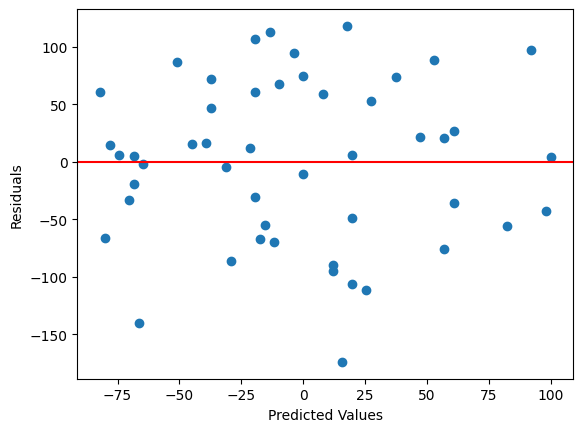

```python
model = sm.OLS(Y_heteroscedastic_diff, sm.add_constant(X[1:])).fit()
B0, B1 = model.params
residuals = model.resid

plt.scatter(model.predict(), residuals);
plt.axhline(0, color='red')
plt.xlabel('Predicted Values');
plt.ylabel('Residuals');
```

```python
breusch_pagan_p = smd.het_breuschpagan(residuals, model.model.exog)[1]
print(breusch_pagan_p)
if breusch_pagan_p > 0.05:
    print("The relationship is not heteroscedastic.")
if breusch_pagan_p < 0.05:
    print("The relationship is heteroscedastic.")
```

```
0.5905424310710394
The relationship is not heteroscedastic.
```

*Lưu ý: Phân tích hồi quy mới này được thực hiện trên sự khác biệt giữa các dữ liệu, do đó, đầu ra của hồi quy cần được chuyển đổi lại để đạt được dự đoán trên thang đo gốc. Vì chúng ta đã hồi quy các sự khác biệt, nên chúng ta có thể cộng sự khác biệt dự đoán của mình vào dữ liệu gốc để có được ước lượng của chúng ta:*

$$\hat{Y_i} = Y_{i-1} + \hat{Y}_{diff}$$

#### Biến đổi Logarit

Tiếp theo, chúng ta áp dụng một biến đổi logarit cho dữ liệu cơ sở. Một biến đổi logarit sẽ làm cho các phần dư gần lại với nhau hơn và lý tưởng là loại bỏ tính không đồng nhất về phương sai. Trong nhiều trường hợp (mặc dù không phải tất cả), một biến đổi logarit là đủ để ổn định phương sai của một mối quan hệ.

```python
# Taking the log of the previous data Y_heteroscedastic and saving it in Y_heteroscedastic_log
Y_heteroscedastic_log = np.log(Y_heteroscedastic)
```

Bây giờ chúng ta đã lưu phiên bản đã được biến đổi log của `Y_heteroscedastic` trong `Y_heteroscedastic_log`, hãy lặp lại hồi quy và biểu đồ phần dư để xem liệu hiện tượng phương sai không đồng nhất có còn tồn tại hay không.

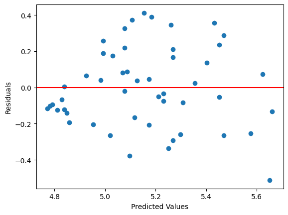

```python
model = sm.OLS(Y_heteroscedastic_log, sm.add_constant(X)).fit()
B0, B1 = model.params
residuals = model.resid

plt.scatter(model.predict(), residuals);
plt.axhline(0, color='red')
plt.xlabel('Predicted Values');
plt.ylabel('Residuals');
```

```python
# Running and interpreting a Breusch-Pagan test
breusch_pagan_p = smd.het_breuschpagan(residuals, model.model.exog)[1]
print(breusch_pagan_p)
if breusch_pagan_p > 0.05:
    print("The relationship is not heteroscedastic.")
if breusch_pagan_p < 0.05:
    print("The relationship is heteroscedastic.")
```

```
0.022649379740285983
The relationship is heteroscedastic.
```

*Lưu ý: Phân tích hồi quy mới này được thực hiện trên log của dữ liệu gốc. Điều này có nghĩa là tỷ lệ đã được thay đổi và các ước lượng hồi quy sẽ nằm trên tỷ lệ đã được biến đổi này. Để đưa các ước lượng trở lại tỷ lệ gốc, bạn phải biến đổi ngược các giá trị bằng cách sử dụng nghịch đảo của log:*

$$\hat{Y} = e^{\log(\hat{Y})}$$

#### Biến đổi Box-Cox

Cuối cùng, chúng ta sẽ xem xét biến đổi Box-Cox. Biến đổi Box-Cox là một phương pháp mạnh mẽ có thể áp dụng cho nhiều loại quan hệ không đồng nhất. Quá trình này hoạt động bằng cách kiểm tra tất cả các giá trị của $\lambda$ trong khoảng $[-5, 5]$ để xem giá trị nào làm cho đầu ra của phương trình sau gần như phân phối chuẩn nhất: $$ Y^{(\lambda)} = \begin{cases} \frac{Y^{\lambda}-1}{\lambda} & : \lambda \neq 0\\ \log{Y} & : \lambda = 0 \end{cases} $$

Giá trị "$\lambda$" "tốt nhất" sẽ được sử dụng để biến đổi chuỗi theo hàm trên. Thay vì phải thực hiện tất cả những điều này một cách thủ công, chúng ta có thể đơn giản sử dụng hàm `boxcox` từ thư viện `scipy`. Chúng ta sử dụng điều này để điều chỉnh $Y$ và hy vọng loại bỏ tính không đồng nhất.

*Lưu ý: Biến đổi Box-Cox chỉ có thể được sử dụng nếu tất cả dữ liệu đều dương.*

```python
# Finding a power transformation adjusted Y_heteroscedastic
Y_heteroscedastic_box_cox = stats.boxcox(Y_heteroscedastic)[0]
```

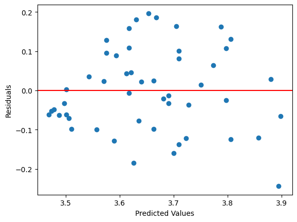

```python
model = sm.OLS(Y_heteroscedastic_box_cox, sm.add_constant(X)).fit()
B0, B1 = model.params
residuals = model.resid

plt.scatter(model.predict(), residuals);
plt.axhline(0, color='red')
plt.xlabel('Predicted Values');
plt.ylabel('Residuals');
```

```python
# Running and interpreting a Breusch-Pagan test
breusch_pagan_p = smd.het_breuschpagan(residuals, model.model.exog)[1]
print(breusch_pagan_p)
if breusch_pagan_p > 0.05:
    print("The relationship is not heteroscedastic.")
if breusch_pagan_p < 0.05:
    print("The relationship is heteroscedastic.")
```

```
0.03842737538502589
The relationship is heteroscedastic.
```

*Lưu ý: Vì dữ liệu đã được biến đổi theo lũy thừa, các ước lượng hồi quy sẽ nằm trên một thang đo khác so với dữ liệu gốc. Đó là lý do tại sao điều quan trọng là nhớ phải biến đổi ngược các kết quả bằng cách sử dụng hàm ngược của Box-Cox:*

$$\hat{Y} = (Y^{(\lambda)}\lambda + 1)^{1/\lambda}$$

### Mô hình GARCH

Một phương pháp khác để xử lý tính không đồng nhất là thông qua mô hình GARCH (tính không đồng nhất điều kiện tự hồi quy tổng quát). Thông tin chi tiết có thể được tìm thấy trong bài giảng về mô hình GARCH.

## Phần dư và Tự tương quan

Một giả định khác của hồi quy tuyến tính là các phần dư không có tự tương quan. Một chuỗi được gọi là tự tương quan khi nó có mối tương quan với phiên bản trễ của chính nó. Một ví dụ về chuỗi thời gian có thể có tự tương quan là nhiệt độ cao hàng ngày. Nhiệt độ hôm nay cung cấp cho bạn thông tin về nhiệt độ ngày mai với độ tin cậy hợp lý (ví dụ: nếu hôm nay là 90 °F, bạn có thể rất tự tin rằng ngày mai sẽ không dưới điểm đóng băng). Tuy nhiên, một chuỗi các lần ném xúc xắc công bằng sẽ không có tự tương quan vì việc nhìn thấy một lần ném không cung cấp cho bạn thông tin về lần ném tiếp theo. Mỗi lần ném là độc lập với lần trước đó.

Trong tài chính, giá cổ phiếu thường có sự tự tương quan trong khi lợi nhuận cổ phiếu thì độc lập từ ngày này sang ngày khác. Chúng ta thể hiện sự phụ thuộc theo thời gian vào các giá trị trước đó như sau:

$$Y_i = Y_{i-1} + \epsilon$$

Nếu các phần dư của một mô hình có tự tương quan, bạn sẽ có khả năng đưa ra dự đoán về các phần dư liền kề. Trong trường hợp của $Y$, chúng ta biết dữ liệu sẽ có tự tương quan vì chúng ta có thể đưa ra dự đoán dựa trên các phần dư liền kề gần nhau.

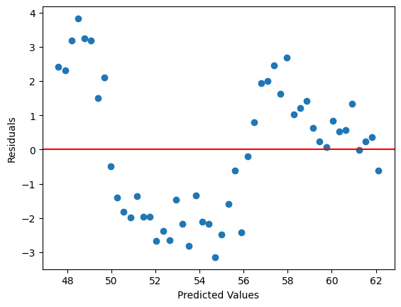

```python
n = 50
X = np.linspace(0, n, n)
Y_autocorrelated = np.zeros(n)
Y_autocorrelated[0] = 50
for t in range(1, n):
    Y_autocorrelated[t] = Y_autocorrelated[t-1] + np.random.normal(0, 1)

# Regressing X and Y_autocorrelated
model = sm.OLS(Y_autocorrelated, sm.add_constant(X)).fit()
B0, B1 = model.params
residuals = model.resid

plt.scatter(model.predict(), residuals);
plt.axhline(0, color='red')
plt.xlabel('Predicted Values');
plt.ylabel('Residuals');
```

### Phương pháp thống kê để phát hiện tự tương quan

Như với tất cả các thuộc tính thống kê, chúng ta cần một bài kiểm tra thống kê để cuối cùng quyết định xem có tự tương quan trong các phần dư của chúng ta hay không. Để làm điều này, chúng ta sử dụng bài kiểm tra Ljung-Box.

Bài kiểm tra Ljung-Box được sử dụng để phát hiện tự tương quan trong một chuỗi thời gian. Bài kiểm tra Ljung-Box kiểm tra tự tương quan ở tất cả các khoảng trễ dưới mức tối đa đã chỉ định và trả về các mảng chứa các kết quả cho từng khoảng trễ đã kiểm tra.

Hãy sử dụng hàm `acorr_ljungbox` trong `statsmodels` để kiểm tra tự tương quan trong các phần dư của mô hình ở trên của chúng ta. Chúng ta sử dụng khoảng trễ tối đa là $10$, và xem liệu có bất kỳ khoảng trễ nào có tự tương quan đáng kể hay không:

```python
ljung_box = smd.acorr_ljungbox(residuals, lags=10, return_df=True)
print("Lagrange Multiplier Statistics:", ljung_box.lb_stat.tolist())
print("\nP-values:", ljung_box.lb_pvalue.tolist(), "\n")

if (ljung_box.lb_pvalue < 0.05).any():
    print("The residuals are autocorrelated.")
else:
    print("The residuals are not autocorrelated.")
```

```
Lagrange Multiplier Statistics: [40.1476440773963, 74.25104708140812, 98.46764601024371, 113.85870682080761, 121.63939025244107, 124.278837855547, 124.72356538667138, 124.72575473906801, 125.11334662762765, 126.57699575707258]

P-values: [2.3547530135363496e-10, 7.526446666478923e-17, 3.318596210573976e-21, 1.0934391930343102e-23, 1.4107124314500556e-24, 2.0552911024095203e-24, 7.939954153484954e-24, 3.498063678450633e-23, 1.1964081006008087e-22, 2.32873344365425e-22]

The residuals are autocorrelated.
```

Bởi vì kiểm định Ljung-Box cho ra giá trị p nhỏ hơn $0.05$ cho ít nhất một khoảng lags, chúng ta có thể kết luận rằng các phần dư của mô hình của chúng ta có tính tự tương quan.

## Điều chỉnh cho Tự tương quan

Chúng ta có thể điều chỉnh cho tự tương quan bằng nhiều cách tương tự như cách chúng ta điều chỉnh cho độ phân tán không đồng nhất. Hãy xem liệu một mô hình trên các sai khác bậc nhất của $Y$ có residual tự tương quan hay không:

```python
# Finding first-order differences in Y_autocorrelated
Y_autocorrelated_diff = np.diff(Y_autocorrelated)
```

```
P-values: [0.09743245365658745, 0.10726265322469263, 0.21279371876463635, 0.2794445625141629, 0.4034917072774137, 0.5139417893165048, 0.3817644516573596, 0.4719654634771462, 0.5540039990649532, 0.5589767542183246]

The residuals are not autocorrelated.
```

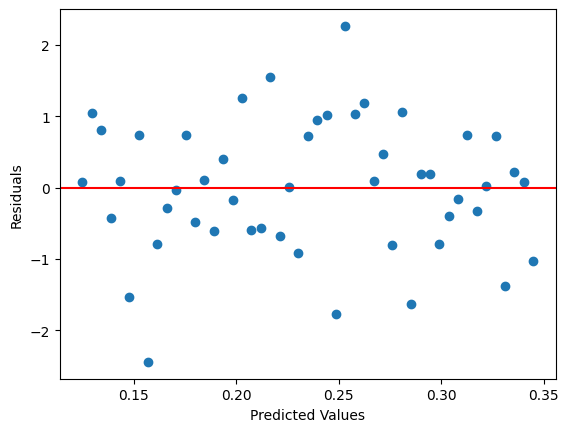

```python
model = sm.OLS(Y_autocorrelated_diff, sm.add_constant(X[1:])).fit()
B0, B1 = model.params
residuals = model.resid

plt.scatter(model.predict(), residuals);
plt.axhline(0, color='red')
plt.xlabel('Predicted Values');
plt.ylabel('Residuals');

# Running and interpreting a Ljung-Box test
ljung_box = smd.acorr_ljungbox(residuals, lags=10, return_df=True)
print("P-values:", ljung_box.lb_pvalue.tolist(), "\n")

if (ljung_box.lb_pvalue < 0.05).any():
    print("The residuals are autocorrelated.")
else:
    print("The residuals are not autocorrelated.")
```

*Lưu ý: Phân tích hồi quy mới này được thực hiện trên sự khác biệt giữa các dữ liệu, vì vậy đầu ra hồi quy phải được chuyển đổi lại để đạt được dự đoán trên thang đo gốc. Vì chúng ta đã hồi quy các sự khác biệt, chúng ta có thể cộng sự khác biệt dự đoán của mình vào dữ liệu gốc để có được ước lượng của mình:*

$$\hat{Y_i} = Y_{i-1} + \hat{Y_{diff}}$$

Chúng ta cũng có thể thực hiện một phép biến đổi logarit, nếu chúng ta muốn. Quá trình này giống hệt như những gì chúng ta đã thực hiện trên dữ liệu không đồng nhất ở trên, vì vậy lần này chúng ta sẽ bỏ qua.

## Ví dụ: Tính Toán Beta Thị Trường

Hãy tính toán beta thị trường giữa SSI và VNINDEX bằng cách sử dụng hồi quy tuyến tính đơn giản, và sau đó tiến hành phân tích phần dư trên hồi quy để đảm bảo tính hợp lệ của kết quả. Để hồi quy SSI và VNINDEX, chúng ta sẽ tập trung vào lợi nhuận của chúng, không phải giá cả, và đặt lợi nhuận của VNINDEX là biến độc lập và lợi nhuận của SSI là biến kết quả. Hồi quy sẽ cho chúng ta một đường phù hợp tốt nhất:

$$\hat{r_{SSI}} = \hat{\beta_0} + \hat{\beta_1}r_{VNINDEX}$$

Độ dốc của đường hồi quy $\hat{\beta_1}$ sẽ đại diện cho beta thị trường của chúng ta, vì đối với mỗi thay đổi $r$ phần trăm trong lợi nhuận của VNINDEX, lợi nhuận dự đoán của SSI sẽ thay đổi theo $\hat{\beta_1}$.

Hãy bắt đầu bằng cách thực hiện hồi quy lợi nhuận của hai tài sản.

```python
# Cài thư viện lấy dữ liệu miễn phí
!curl -fsSLO https://raw.githubusercontent.com/algo-stocks/data/master/data.py
```

```
Estimated SSI Beta: 1.5968374559671217
```

[figure not shown]

```python
from data import get_prices

start = '2021-01-01'
end = '2022-01-01'

closes = get_prices('SSI', 'VNINDEX', start_date=start, end_date=end).dropna()

asset = closes['SSI']
benchmark = closes['VNINDEX']

# We have to take the percent changes to get to returns
# Get rid of the first (0th) element because it is NAN
r_a = asset.pct_change()[1:].values
r_b = benchmark.pct_change(fill_method=None)[1:].values

# Regressing the benchmark b and asset a
r_b = sm.add_constant(r_b)
model = sm.OLS(r_a, r_b).fit()
r_b = r_b[:, 1]
B0, B1 = model.params

# Plotting the regression
A_hat = (B1*r_b + B0)
plt.scatter(r_b, r_a, alpha=1) # Plot the raw data
plt.plot(r_b, A_hat, 'r', alpha=1);  # Add the regression line, colored in red
plt.xlabel('SSI Returns')
plt.ylabel('VNINDEX Returns')

# Print our result
print("Estimated SSI Beta:", B1)

# Calculating the residuals
residuals = model.resid
```

Hồi quy của chúng ta cho thấy một beta thị trường ước tính là 1,59; theo hồi quy, cho mỗi 1% lợi nhuận mà chúng ta thấy từ VNINDEX, chúng ta nên thấy 1,59% từ SSI.

Bây giờ chúng ta đã có kết quả hồi quy và phần dư, chúng ta có thể tiến hành phân tích phần dư. Bước đầu tiên của chúng ta sẽ là vẽ biểu đồ phần dư và tìm kiếm bất kỳ dấu hiệu đáng ngờ nào.

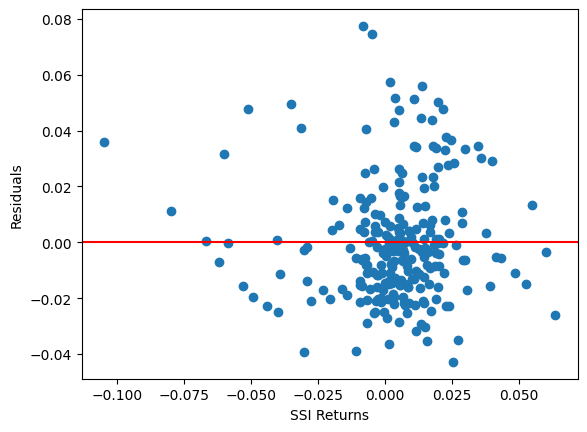

```python
plt.scatter(model.predict(), residuals);
plt.axhline(0, color='red')
plt.xlabel('SSI Returns');
plt.ylabel('Residuals');
```

Bằng cách đơn giản quan sát phân phối của các phần dư, dường như không có bất kỳ bất thường nào. Phân phối tương đối ngẫu nhiên và không có mẫu nào có thể được quan sát (sự tập trung xung quanh gốc tọa độ là kết quả của bản chất của lợi suất khi tập trung quanh 0 và không phải là một dấu hiệu đáng ngờ). Kết luận định tính của chúng tôi là dữ liệu là đồng phương sai và không có tự tương quan, do đó thỏa mãn các giả định cho hồi quy tuyến tính.

## Kiểm định Heteroscedasticity Breusch-Pagan

Đánh giá định tính của chúng tôi về biểu đồ phần dư được bổ sung tốt bởi một vài bài kiểm tra thống kê. Hãy bắt đầu bằng cách kiểm tra heteroscedasticity sử dụng bài kiểm tra Breusch-Pagan. Sử dụng hàm `het_breuschpagan` từ gói statsmodels:

```python
bp_test = smd.het_breuschpagan(residuals, model.model.exog)

print("Lagrange Multiplier Statistic:", bp_test[0])
print("P-value:", bp_test[1])
print("f-value:", bp_test[2])
print("f_p-value:", bp_test[3], "\n")
if bp_test[1] > 0.05:
    print("The relationship is not heteroscedastic.")
if bp_test[1] < 0.05:
    print("The relationship is heteroscedastic.")
```

```
Lagrange Multiplier Statistic: 0.40793893953302907
P-value: 0.5230174762490993
f-value: 0.4053263713846116
f_p-value: 0.524940806854286

The relationship is not heteroscedastic.
```

Bởi vì giá trị P lớn hơn 0.05, chúng ta không có đủ bằng chứng để bác bỏ giả thuyết không rằng mối quan hệ là đồng phương sai. Kết quả này phù hợp với kết luận định tính của chúng ta.

## Kiểm định Tự tương quan Ljung-Box

```python
ljung_box = smd.acorr_ljungbox(r_a, lags=1, return_df=True)
print("P-Values:", ljung_box.lb_pvalue.tolist(), "\n")
if (ljung_box.lb_pvalue < 0.05).any():
    print("The residuals are autocorrelated.")
else:
    print("The residuals are not autocorrelated.")
```

```
P-Values: [0.6585927765047188]

The residuals are not autocorrelated.
```

## Tham khảo

- "Analysis of Financial Time Series", by Ruey Tsay

*Lưu ý: Tài liệu này mang tính chất chia sẻ kiến thức khoa học dữ liệu. Các mã chứng khoán xuất hiện trong tài liệu chỉ mang tính chất minh hoạ, không khuyến nghị đầu tư. Chúng tôi không chịu trách nhiệm trước mọi rủi ro nào do sử dụng tài liệu này.*